# DAB 502 : LAB 1

## Pallavi Ravikumar Menon

### I. Load packages

```r
library(tidyverse)
library(here)
```

### II. Exercises

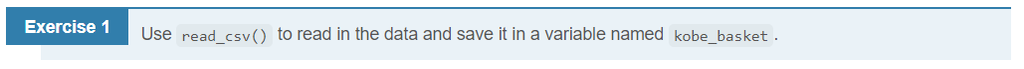

```r
kobe_basket <- read.csv("kobe_HM.csv")
```

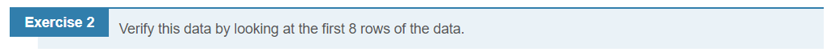

```r
head(kobe_basket,9)
```

```
##    vs game quarter     time
## 1 ORL    1       1 09:47:00
## 2 ORL    1       1 09:07:00
## 3 ORL    1       1 08:11:00
## 4 ORL    1       1 07:41:00
## 5 ORL    1       1 07:03:00
## 6 ORL    1       1 06:01:00
## 7 ORL    1       1 04:07:00
## 8 ORL    1       1 00:52:00
## 9 ORL    1       1 00:00:00
##                                               description shot
## 1                 Kobe Bryant makes 4-foot two point shot    H
## 2                               Kobe Bryant misses jumper    M
## 3                        Kobe Bryant misses 7-foot jumper    M
## 4 Kobe Bryant makes 16-foot jumper (Derek Fisher assists)    H
## 5                         Kobe Bryant makes driving layup    H
## 6                               Kobe Bryant misses jumper    M
## 7                       Kobe Bryant misses 12-foot jumper    M
## 8                       Kobe Bryant misses 19-foot jumper    M
## 9                                Kobe Bryant misses layup    M
```

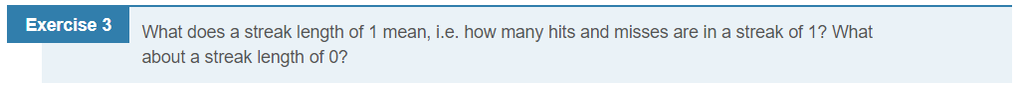

```r
calc_streak <- function(x){
  y <- rep(0,length(x))
  y[x == "H"] <- 1
  y <- c(0, y, 0)
  wz <- which(y == 0)
  streak <- diff(wz) - 1
  return(streak)
}

kobe_streak <- tibble(length = calc_streak(kobe_basket$shot))
```

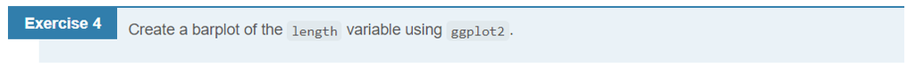

[figure not shown]

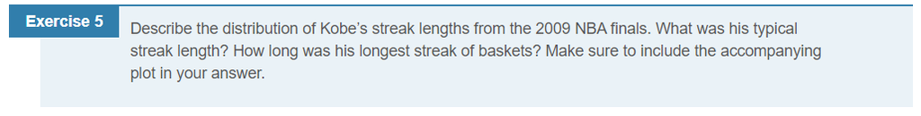

```r
ggplot(kobe_streak,aes(length)) +
  geom_bar() +
  ggtitle("Distribution of streak lengths") + theme_minimal() + theme(plot.title = element_text (hjust = 0.5))
```

**1) The distribution is unimodal and right skewed.**

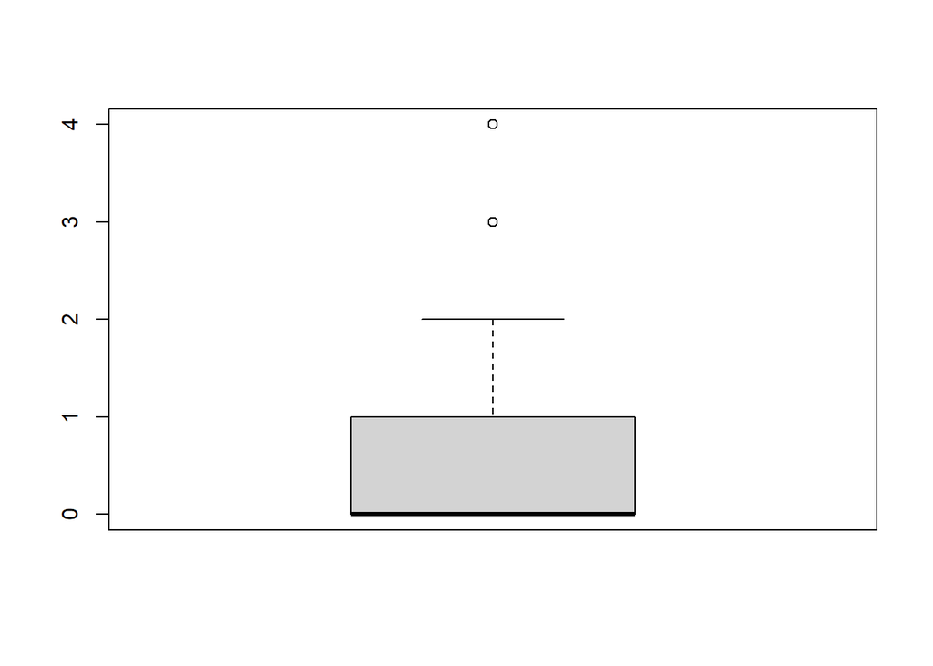

```
The following questions are answered based on the above plot:
```

```r
boxplot(kobe_streak)
```

```r
IQR(calc_streak(kobe_basket$shot))
```

```
## [1] 1
```

**3) As observed from the plot above, Kobe’s longest streak was basket was were 4.**

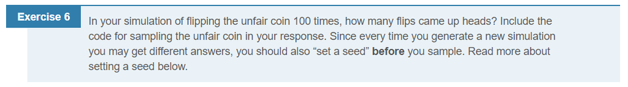

**As we can see after setting the seed and running the simulation of flipping the unfair coin 100 times. We get output table that shows the number of flips that came up as heads are 16**

```r
coin_outcomes <- c("heads", "tails")

set.seed(45686)

sim_unfair_coin <- sample(coin_outcomes, size = 100, replace = TRUE, prob = c(0.2, 0.8))

table(sim_unfair_coin)
```

```
## sim_unfair_coin
## heads tails
##    16    84
```

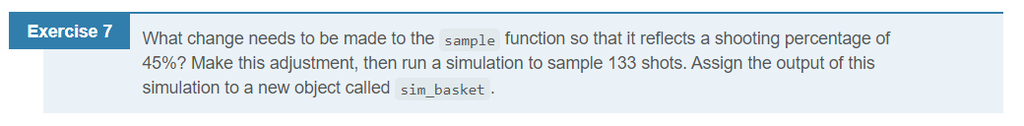

**Former function :**

```r
shot_outcomes <- c("H", "M")
sim_basket <- sample(shot_outcomes, size = 1, replace = TRUE)
```

**The changes have to be made to the former function to reflect shooting percentage of 45%**

```r
outcomes <- c("H", "M")
sim_basket <- sample(outcomes, size = 133, replace=TRUE, prob = c(0.45,0.55))
```

```r
sim_basket
```

```
##   [1] "M" "H" "H" "M" "H" "H" "H" "M" "M" "H" "M" "H" "M" "M" "H" "M" "M" "M"
##  [19] "M" "M" "M" "H" "H" "H" "M" "M" "M" "M" "M" "H" "M" "M" "M" "M" "H" "H"
##  [37] "M" "M" "M" "H" "M" "M" "M" "H" "H" "M" "M" "M" "M" "M" "M" "M" "M" "M"
##  [55] "M" "M" "M" "H" "H" "H" "M" "M" "M" "H" "M" "H" "M" "M" "H" "M" "M" "M"
##  [73] "M" "M" "H" "M" "M" "H" "H" "M" "H" "M" "H" "M" "H" "H" "M" "M" "M" "H"
##  [91] "M" "H" "M" "M" "M" "H" "H" "H" "H" "H" "H" "M" "H" "M" "M" "M" "M" "H"
## [109] "H" "H" "M" "M" "M" "H" "M" "M" "H" "H" "M" "H" "H" "M" "M" "H" "M" "M"
## [127] "H" "M" "H" "H" "H" "M" "M"
```

```r
table(sim_basket)
```

```
## sim_basket
##  H  M
## 52 81
```

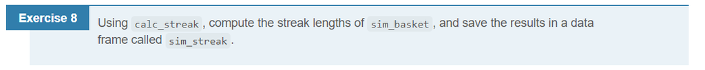

```r
sim_streak <- calc_streak(sim_basket)
sim_streak
```

```
##  [1] 0 2 3 0 1 1 0 1 0 0 0 0 0 3 0 0 0 0 1 0 0 0 2 0 0 1 0 0 2 0 0 0 0 0 0 0 0 0
## [39] 0 0 3 0 0 1 1 0 1 0 0 0 0 1 0 2 1 1 2 0 0 1 1 0 0 6 1 0 0 0 3 0 0 1 0 2 2 0
## [77] 1 0 1 3 0 0
```

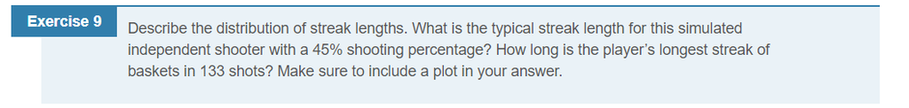

```
We make a bar plot to understand the distribution
```

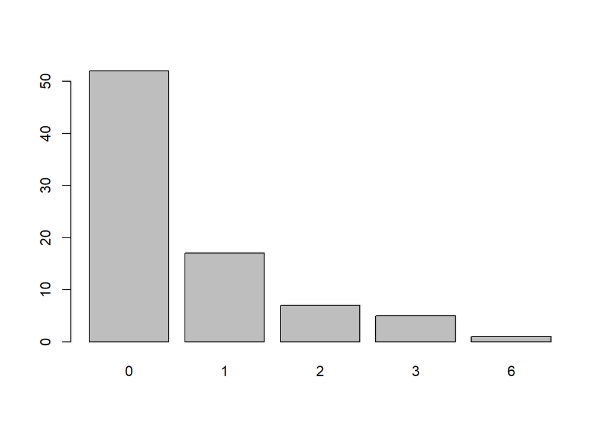

```r
barplot(table(sim_streak))
```

**1) The distribution is unimodal and right skewed.**

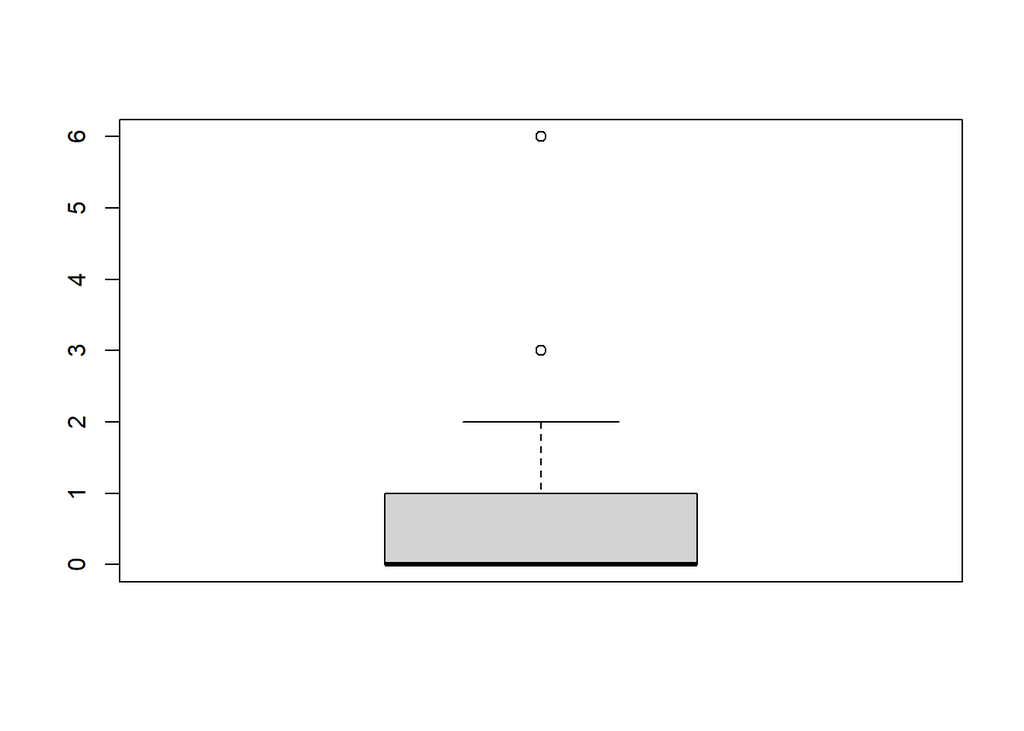

```
The following questions are answered based on the above plot:
```

```r
boxplot(sim_streak)
```

```r
IQR(calc_streak(sim_basket))
```

```
## [1] 1
```

**3) As observed from the plot above, longest streak of the simulated independent player is 6.**

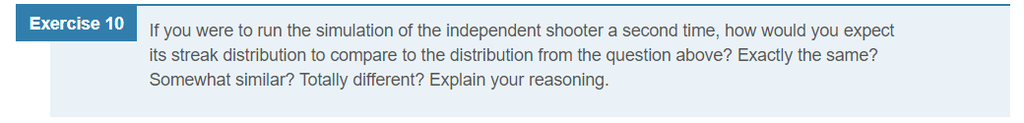

**If i run the simulation again, i expect the results to be slight different as the seed value is not set.However, given the probability of 0.45% and 133 shots it could be closer to the value obtained with the aboove simulation.**

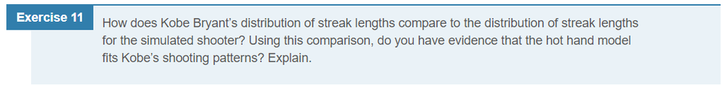

**The streak length observed for both Kobe and independent player differs even though the distribution for both are the same i.e unimodal and right skewed. Also difference in the streak length proves both the events are independent of each other. Hence, there aren’t enough evidence that the hot hand model fits Kobe’s shooting patterns.**